# The Impacts of Ocean Acidification

Winter 2022

### Code Name

Project_Shell

### Authors:

| Name | Email |
| --- | --- |
| Benjamin Nickerson | nickben@uw.edu |
| Caroline Wills | cwills07@uw.edu |
| Raina Scherer | rainacs@uw.edu |
| Zach Kornas | zkornas@uw.edu |

### Affiliation

INFO-201: Technical Foundations of Informatics - The Information School - University of Washington

## Abstract

The main question of this project is identifying the impacts and effects of ocean acidification on global ecosystems and economies. This question of examining the impacts of ocean acidification is important because ocean acidification threatens marine ecosystems, coastal communities, and the global economy. To address this question we will compare different datasets that record pH levels of different bodies of water and the ramifications of ocean acidification on marine life and shellfish industry.

## Keywords

- Climate change
- Ocean Ecosystems
- Ocean Acidification
- CO2
- Economy
- Sea Life

## 1.0 Introduction

Ocean acidification is a reduction in the pH levels over an extended period of time caused by an uptake of carbon dioxide (CO2) from the atmosphere. The intake of C02 concentration in the atmosphere has increased through anthropogenic processes such as the burning of fossil fuels and land use change since the Industrial Revolution. With an increased amount of CO2 being absorbed into the oceans, it causes seawater acidification resulting in less carbonate ions which are the building blocks for many marine organisms. Less carbonate ions and seawater acidification as a result of ocean acidification significantly decreases the calcium carbonate structures difficult for calcifying organisms threatening marine organisms and ecosystems. Ocean acidification negatively affects marine organisms, ecosystems and economies dependent on fishing and shellfish industries. The objective of this project is to inform stakeholders such as constituents, policymakers, and elected officials the adverse effects of ocean acidification on global economic and environmental health by negatively impacting marine ecosystems and industries. We will visualize data to show the changing ocean acid levels, and explain the impact of those levels on different marine ecosystems and the economies that rely on them. We aim to make an argument for the protection of marine life, coastal ecosystems and communities.

## 2.0 Design Situation

#### Project Framing

This project is designed around a global concern of ocean acidification and marine ecosystems by examining the impacts of how anthropogenic production of CO2 impacts aquatic and human health from ecological and economic viewpoints. This is a project of comparisons, aimed to reveal the correlations between different datasets to create a broader understanding of the various ways in which people and the environment are impacted.

#### Human Values

The human values of this project encompass a comprehensive set of values concerning human interactions and impacts on the physical environment. The main value of this project is to improve global environmental sustainability and stewardship as ocean acidification harms marine ecosystems and coastal communities. The other human value of this project is climate justice as ocean acidification threatens livelihood, food security, socio-economic security and coastal communities.

#### Direct Stakeholders

The direct stakeholders of this project include our workgroup, the teaching team, and any users of the end data project such as policymakers and constituents..

#### Indirect Stakeholders

The indirect stakeholders of the end data user product include as environmental and aquatic health concerns the worldwide population. In particular the project focuses on impacts of ocean acidification affecting shellfish industry professionals, communities who depend on marine life as a food source, and coastal groups of people.

#### Possible Harms and Benefits

Our goal for this project is that it will benefit the public and politicians by providing important data on the current effects of ocean acidification, leading to increased interest in the issue and a broader effort to address this problem. A possible harm of our work could come from a lack of particular expertise in oceanography, leading us to miss important information or ask the wrong questions of our data. This, in turn, could direct stakeholderâs attention away from more actionable issues and towards what this project focuses on. Through this project, the hope is to reduce the risk of harm from ocean acidification by consulting existing research on ocean acidification and human impact, in order to become more well-informed as to the current body of knowledge.

## 3.0 Research Questions

- The first question is: **What is the current ocean pH level in seawater and how has it changed?**
- This question reveals the chronological changes of pH levels within seawater.
- The second question is: **How will the changes in pH levels impact marine ecosystems?**
- This question allows the user to understand how changes in seawater acidification revealed through pH levels negatively affect marine organisms and ecosystems.
- The third question is: **How will humans, human industries, and economies be impacted by the changes within marine ecosystems from ocean acidification?**
- This question is important because it allows the user to understand the magnitude of the impacts of ocean acidification on marine ecosystems and economies.

## 4.0 The Dataset

#### Origin

The dataset used for this project to analyze the implications of ocean acidification is from the National Centers for Environmental Information [Coastal Open Data Analysis Product in North America](https://www.ncei.noaa.gov/data/oceans/ncei/ocads/metadata/0219960.html). This dataset was recorded along the seawater shorelines bordering North America. The purpose of this dataset is to record the changes of seawater acidification through specific oceanic parameter variables along the entire continental shelves of North America over the span of nearly two decades (Jiang, 2021). According to Dr. Richard A. Feely the intention of this dataset is to help coastal enterprises and decision-makers develop strategies to adapt to the severity of ocean acidification and promote more OA research within the U.S. Exclusive Economic Zone (Jiang, 2021).

#### Complexity

The first dataset is complied of 14 different chemical variables and oceanic parameters within of ocean acidifcation including temperature, salinity, oxygen, nutrients, pH, calcium carbonate mineral saturation states, dissolved inorganic carbon, and total alkalinity depicting the impacts of ocean acidification through the changes in pH levels and other chemical chain reaction variables. It is important to note as well that the data was collected from multiple sites along the North American coasts, increasing the overall complexity of the data and allowing us to gain insight into the greater impact of ocean acidification. By comparing this dataset to recent data on environmental and economic impacts recorded specifically within coastal communities and shellfish industries during the time of documentation of the dataset, the impacts of ocean acidification can be identified and understood.

#### Size

The first dataset is collected over two decades made up of over 3,000 oceanographic profiles from 61 research ships. There are over 28,000 observations made in the dataset, each with multiple oceanic parameter variables recorded.

#### A quick look at our data

| Year | Avg. Arctic pH | Avg. Atlantic pH | Avg. Pacific pH |
| --- | --- | --- | --- |
| 2004 | NA | 8.07 | NA |
| 2005 | NA | 8.11 | NA |
| 2006 | NA | 8.11 | NA |
| 2007 | NA | 8.00 | 7.81 |
| 2008 | NA | NA | 8.07 |
| 2009 | NA | NA | 8.00 |
| 2010 | 8.21 | NA | 8.08 |
| 2011 | NA | NA | 7.78 |
| 2012 | 8.04 | 7.99 | 7.81 |
| 2013 | 8.14 | 7.97 | 7.83 |
| 2014 | NA | 7.99 | NA |
| 2015 | NA | 7.99 | 7.95 |
| 2016 | NA | 7.94 | 7.83 |
| 2017 | NA | 7.97 | 7.81 |
| 2018 | NA | 8.00 | NA |

#### Preliminary Look at Important Observations

In 2018, the average pH of our oceans was 8.  
In 2004, the average pH of our oceans was 8.07.  
The decrease of -0.07 may not seem like much, but considering that the pH scale is logarithmic and many forms of life rely on a very tiny range of pH variance, this is a huge increase in acidity.

The most observations came from the Latitude and Longitude 27.8697 -93.83, or roughly the middle of the gulf of mexico.  
2012 Was the highest measured CO2 fungacity (roughly, vapor pressure).

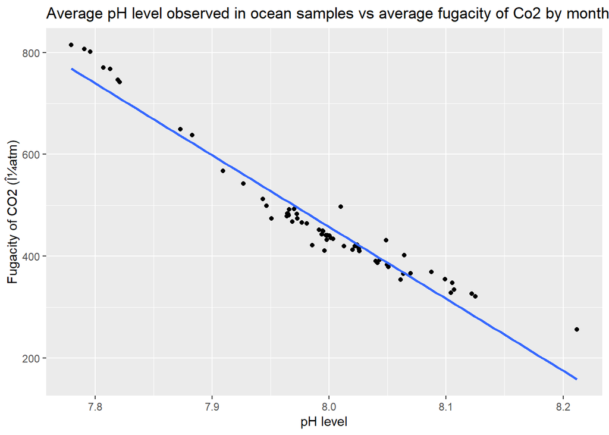

For this chart we decided to create a scatter plot to show the pH level (x axis) vs the average concentration of CO2 dissolved in the water. We calculated the average pH level and average concentration of CO2 for each month and plotted them on a graph. We were attempting to see if there is a correlation between the pH level and amount of dissolved carbon dioxide in ocean water. We are able to see a clear trend downward. When the average pH level is higher, the amount of dissolved carbon dioxide is lower, so the more CO2 that is absorbed into the ocean the more acidic the ocean becomes.

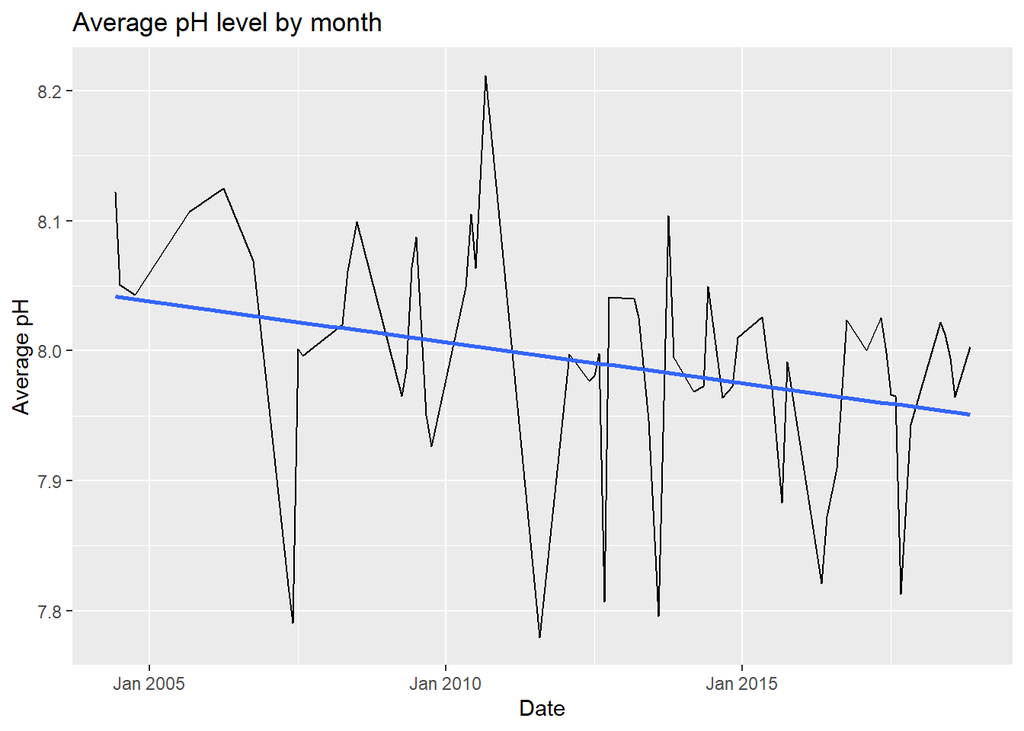

We decided to create a line chart in an attempt to show the pH level change over the course of time. We thought a line chart was the best way to visualize this data. It is important to track the pH level as this may give us insight into how the ocean’s acidity is changing over time, and a chart showing the readings over time is the best way to visualize this data. We are able to see a clear trend downward in pH over time, meaning that the ocean samples become more acidic as time goes on.

[interactive chart not shown]

In this map we show where each of our samples were taken. This gives good perspective to what kind of data we are analyzing, in that most of it is taken from areas close to shorelines. This is likely for two reasons, the first being that it is not practical to take measurements in the middle of the ocean, and that the data gathered 100 miles vs 2000 miles from shore is likely not radically different. Additionally, this map shows the defined range of each ocean so results may be analyzed by region.

## 5.0 Expected Implications

Ocean acidification decreases the amount of carbonate which is a key building block for marine organisms making it difficult for marine organisms such as plankton and coral to form shells and skeletons. Ocean acidification has economic and societal impacts as well by impacting the fishing industry and tourism. Ocean acidification also threatens coral reefs which are imperative to our survival because we rely on them for food, coastal protection, medicines and tourism dollars. The corrosion of oceans through CO2 emissions alters marine resources availability indirectly leading to job losses within the fishing industry and directly impacting the way of life for coastal communities. The indirect and direct implications of ocean acidification show that it is an increasing global threat from policymakers and coastal communities to the fishing industry.

## 6.0 Limitations

While this project can provide valuable research and insight on the impacts of ocean acidification, there are some limitations that we need to address. Currently, the data that we collected only contains observations made by oceanographers along the North American coast. Marine life in North American aquatic ecosystems can differ from that of other oceanic regions. This limits our ability to apply our findings beyond the scope of aquatic ecosystems on the North American coast. Another limitation that should be considered is that ocean acidification is a relatively recent phenomenon (Smithsonian, 2019). While data can be found regarding the recent increase in ocean acidification and a correlation to an impact in marine life, it may be difficult to extend these conclusions beyond our immediate observations. It is difficult to draw conclusions about how future marine life will be affected by current increases in ocean acidificiation.

## Acknowledgements

Thank you to Marina V. in the UW library 24 hour chat for helping us find some helpful datasets!

## References

Jiang, et al. (2021, August 10). Coastal Ocean Data Analysis Product in North America (CODAP-NA, Version 2021) (NCEI Accession 0219960). National Centers for Environmental Information; National Centers for Environmental Information.

Jiang, et al. (2021, June 16). Ocean acidification data for coasts. National Centers for Environmental Information (NCEI). Retrieved February 4, 2022, from https://www.ncei.noaa.gov/news/ocean-acidification-data-coasts

Smithsonian Ocean. (2019, June 20). Ocean Acidification. https://ocean.si.edu/ocean-life/invertebrates/ocean-acidification

Thomas Frank, E&E News. (2020, January 3). Ocean Acidification Threatens the U.S. Economy. Scientific American. Retrieved March 2, 2022, from https://www.scientificamerican.com/article/ocean-acidification-threatens-the-u-s-economy/